# Actividad 1: Estadística y R

Yannis Avlonitis Egea

2025-11-19

```r
setwd("C:/Users/yanni/Desktop/MASTER/CUATRI 1/Estadística y R/Act1EyR")
df2 <- read.csv("C:/Users/yanni/Desktop/MASTER/CUATRI 1/Estadística y R/Act1EyR/MUBioinfo_dataset_genes_oct2025.csv")
```

```r
library(readr)
library(ggplot2)
library(pheatmap)
library(ComplexHeatmap)
library(patchwork)
library(dendextend)
```

### **Pregunta 1:**

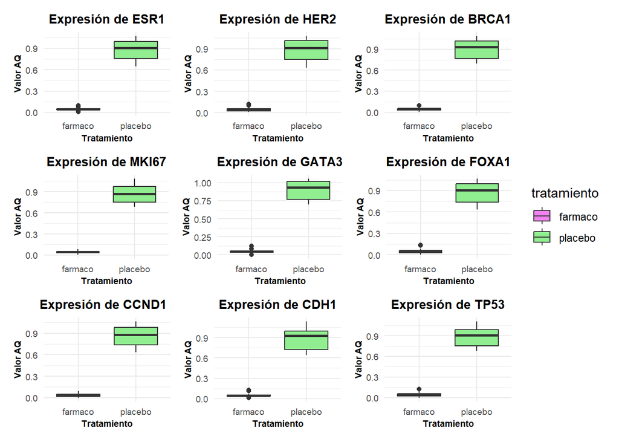

```r
#AQ_ESR1
g0 <- ggplot(data = df2, aes(x = tratamiento, y = AQ_esr1, fill = tratamiento)) +
  geom_boxplot()+
  labs(title = "Expresión de ESR1",
       x = "Tratamiento",
       y = "Valor AQ")+
  theme_minimal()+
  theme(plot.title = element_text(hjust = 0.5,
                                  size = 10,
                                  face = "bold"),
        axis.title.x = element_text(size = 7, face = "bold"),
        axis.title.y = element_text(size = 7, face = "bold"),
        axis.text.x = element_text(size = 7),
        axis.text.y = element_text(size = 7) ) +
  scale_fill_manual(values = c("violet", "lightgreen"))

#AQ_HER2
g1 <- ggplot(data = df2, aes(x = tratamiento, y = AQ_her2, fill = tratamiento)) +
  geom_boxplot()+
  labs(title = "Expresión de HER2",
       x = "Tratamiento",
       y = "Valor AQ")+
  theme_minimal()+
  theme(plot.title = element_text(hjust = 0.5,
                                  size = 10,
                                  face = "bold"),
        axis.title.x = element_text(size = 7, face = "bold"),
        axis.title.y = element_text(size = 7, face = "bold"),
        axis.text.x = element_text(size = 7),
        axis.text.y = element_text(size = 7) ) +
  scale_fill_manual(values = c("violet", "lightgreen"))

#AQ_BRCA1
g2 <- ggplot(data = df2, aes(x = tratamiento, y = AQ_brca1, fill = tratamiento))+
  geom_boxplot()+
  labs(title = "Expresión de BRCA1",
       x = "Tratamiento",
       y = "Valor AQ")+
  theme_minimal()+
  theme(plot.title = element_text(hjust = 0.5,
                                  size = 10,
                                  face = "bold"),
        axis.title.x = element_text(size = 7, face = "bold"),
        axis.title.y = element_text(size = 7, face = "bold"),
        axis.text.x = element_text(size = 7),
        axis.text.y = element_text(size = 7) ) +
  scale_fill_manual(values = c("violet", "lightgreen"))

#AQ_BRCA2
g3 <- ggplot(data = df2, aes(x = tratamiento, y = AQ_brca2, fill = tratamiento))+
  geom_boxplot()+
  labs(title = "Expresión de BRCA2",
       x = "Tratamiento",
       y = "Valor AQ")+
  theme_minimal()+
  theme(plot.title = element_text(hjust = 0.5,
                                  size = 10,
                                  face = "bold"),
        axis.title.x = element_text(size = 7, face = "bold"),
        axis.title.y = element_text(size = 7, face = "bold"),
        axis.text.x = element_text(size = 7),
        axis.text.y = element_text(size = 7) ) +
  scale_fill_manual(values = c("violet", "lightgreen"))

#AQ_MKI67
g4 <- ggplot(data = df2, aes(x = tratamiento, y = AQ_mki67, fill = tratamiento))+
  geom_boxplot()+
  labs(title = "Expresión de MKI67",
       x = "Tratamiento",
       y = "Valor AQ")+
  theme_minimal()+
  theme(plot.title = element_text(hjust = 0.5,
                                  size = 10,
                                  face = "bold"),
        axis.title.x = element_text(size = 7, face = "bold"),
        axis.title.y = element_text(size = 7, face = "bold"),
        axis.text.x = element_text(size = 7),
        axis.text.y = element_text(size = 7) ) +
  scale_fill_manual(values = c("violet", "lightgreen"))

#AQ_GATA3
g5 <- ggplot(data = df2, aes(x = tratamiento, y = AQ_gata3, fill = tratamiento))+
  geom_boxplot()+
  labs(title = "Expresión de GATA3",
       x = "Tratamiento",
       y = "Valor AQ")+
  theme_minimal()+
  theme(plot.title = element_text(hjust = 0.5,
                                  size = 10,
                                  face = "bold"),
        axis.title.x = element_text(size = 7, face = "bold"),
        axis.title.y = element_text(size = 7, face = "bold"),
        axis.text.x = element_text(size = 7),
        axis.text.y = element_text(size = 7) ) +
  scale_fill_manual(values = c("violet", "lightgreen"))

#AQ_FOXA1
g6 <- ggplot(data = df2, aes(x = tratamiento, y = AQ_foxa1, fill = tratamiento))+
  geom_boxplot()+
  labs(title = "Expresión de FOXA1",
       x = "Tratamiento",
       y = "Valor AQ")+
  theme_minimal()+
  theme(plot.title = element_text(hjust = 0.5,
                                  size = 10,
                                  face = "bold"),
        axis.title.x = element_text(size = 7, face = "bold"),
        axis.title.y = element_text(size = 7, face = "bold"),
        axis.text.x = element_text(size = 7),
        axis.text.y = element_text(size = 7) ) +
  scale_fill_manual(values = c("violet", "lightgreen"))

#AQ_ccnd1
g7 <- ggplot(data = df2, aes(x = tratamiento, y = AQ_ccnd1, fill = tratamiento))+
  geom_boxplot()+
  labs(title = "Expresión de CCND1  ",
       x = "Tratamiento",
       y = "Valor AQ")+
  theme_minimal()+
  theme(plot.title = element_text(hjust = 0.5,
                                  size = 10,
                                  face = "bold"),
        axis.title.x = element_text(size = 7, face = "bold"),
        axis.title.y = element_text(size = 7, face = "bold"),
        axis.text.x = element_text(size = 7),
        axis.text.y = element_text(size = 7) ) +
  scale_fill_manual(values = c("violet", "lightgreen"))

#AQ_cdh1
g8 <- ggplot(data = df2, aes(x = tratamiento, y = AQ_cdh1, fill = tratamiento))+
  geom_boxplot()+
  labs(title = "Expresión de CDH1",
       x = "Tratamiento",
       y = "Valor AQ")+
  theme_minimal()+
  theme(plot.title = element_text(hjust = 0.5,
                                  size = 10,
                                  face = "bold"),
        axis.title.x = element_text(size = 7, face = "bold"),
        axis.title.y = element_text(size = 7, face = "bold"),
        axis.text.x = element_text(size = 7),
        axis.text.y = element_text(size = 7) ) +
  scale_fill_manual(values = c("violet", "lightgreen"))

#AQ_TP53
g9 <- ggplot(data = df2, aes(x = tratamiento, y = AQ_tp53, fill = tratamiento))+
  geom_boxplot()+
  labs(title = "Expresión de TP53",
       x = "Tratamiento",
       y = "Valor AQ")+
  theme_minimal()+
  theme(plot.title = element_text(hjust = 0.5,
                                  size = 10,
                                  face = "bold"),
        axis.title.x = element_text(size = 7, face = "bold"),
        axis.title.y = element_text(size = 7, face = "bold"),
        axis.text.x = element_text(size = 7),
        axis.text.y = element_text(size = 7) ) +
  scale_fill_manual(values = c("violet", "lightgreen"))

# Ahora que tengo cada boxplot, los uno con la libreria "patchwork"
((g0 | g1 | g2 ) /
    (g4 | g5 | g6) /
    (g7 | g8 | g9)) +
  plot_layout(guides = "collect")
```

Al observar los diagramas de cajas de los genes seleccionados, se puede observar una clara diferencia en la expresión de los genes estudiados (ESR1, HER2, BRCA1, MKI67, AQ_GATA3, FOXA1, CCND1, CDH1 y TP53) en función de los dos tratamientos “fármaco” y “placebo”.

En el tratamiento “placebo”, el valor AQ de todos los genes se distribuye en torno al 0.8-1.0, significando que su expresión es alta. Esto tiene sentido ya que un placebo no tiene un efecto biológico real en la expresión de genes, por lo que los genes involucrados en el cáncer siguen estando sobreexpresados.

En cambio, en el tratamiento “fármaco”, se puede observar una disminución significativa de los valores AQ de todos los genes, llegando cerca del 0.0. Esta disminución probablemente se debe a que el fármaco administrado está teniendo un efecto, indicando que el gen no está siendo trascrito o que su expresión es extremadamente baja y no detectable por los métodos utilizados.

En conclusión, el tratamiento tiene un efecto global sobre todos los genes involucrados en el cancer de mama estudiado, mientras que el placebo es inocuo.

### **Pregunta 2:**

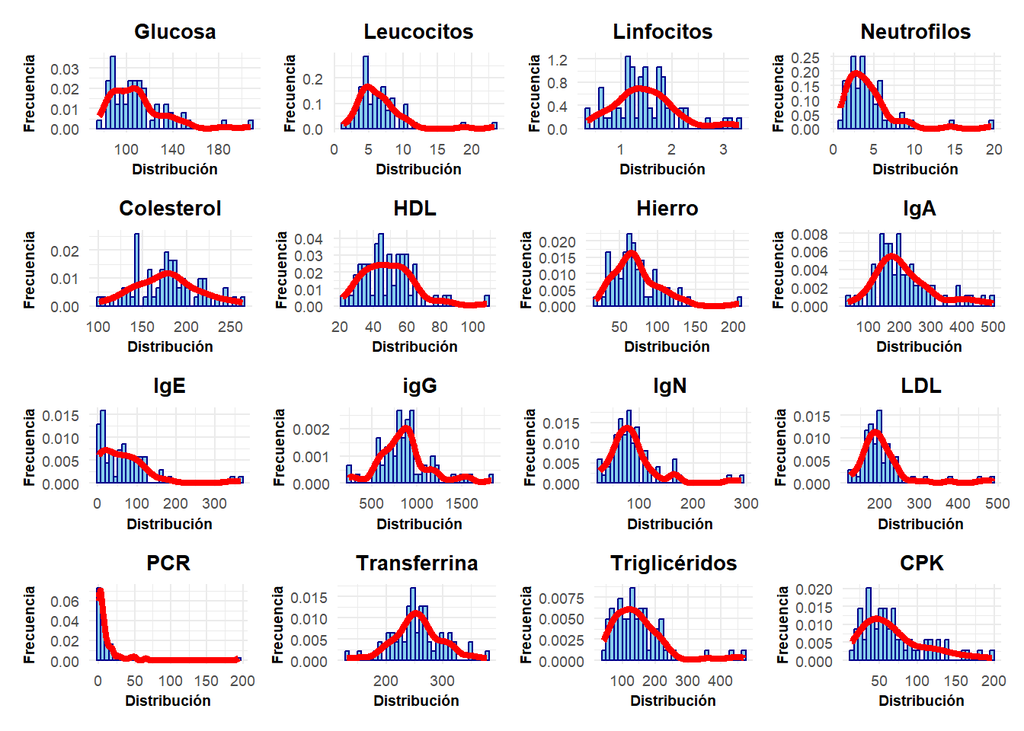

```r
# Glucosa
h1 <- ggplot(df2, aes(x = glucosa))+
  geom_histogram(aes(y = ..density..), fill = "skyblue", color = "darkblue", bins = 35)+
  labs(title = "Glucosa",
      x = "Distribución",
      y = "Frecuencia")+
  geom_density(color = "red",
               size = 1,
               lwd = 1.5)+
  theme_minimal()+
  theme(plot.title = element_text(hjust = 0.5,
                                  size = 10,
                                  face = "bold"),
        axis.title.x = element_text(size = 7, face = "bold"),
        axis.title.y = element_text(size = 7, face = "bold"),
        axis.text.x = element_text(size = 7),
        axis.text.y = element_text(size = 7) )

# Leucocitos
h2 <- ggplot(df2, aes(x = leucocitos))+
  geom_histogram(aes(y = ..density..), fill = "skyblue", color = "darkblue", bins = 35)+
  labs(title = "Leucocitos",
       x = "Distribución",
       y = "Frecuencia")+
  geom_density(color = "red",
               size = 1,
               lwd = 1.5)+
  theme_minimal()+
  theme(plot.title = element_text(hjust = 0.5,
                                  size = 10,
                                  face = "bold"),
        axis.title.x = element_text(size = 7, face = "bold"),
        axis.title.y = element_text(size = 7, face = "bold"),
        axis.text.x = element_text(size = 7),
        axis.text.y = element_text(size = 7) )

# Linfocitos
h3 <- ggplot(df2, aes(x = linfocitos))+
  geom_histogram(aes(y = ..density..), fill = "skyblue", color = "darkblue", bins = 35)+
  labs(title = "Linfocitos",
       x = "Distribución",
       y = "Frecuencia")+
  geom_density(color = "red",
               size = 1,
               lwd = 1.5)+
  theme_minimal()+
  theme(plot.title = element_text(hjust = 0.5,
                                  size = 10,
                                  face = "bold"),
        axis.title.x = element_text(size = 7, face = "bold"),
        axis.title.y = element_text(size = 7, face = "bold"),
        axis.text.x = element_text(size = 7),
        axis.text.y = element_text(size = 7) )

# Neutrófilos
h4 <- ggplot(df2, aes(x = neutrofilos))+
  geom_histogram(aes(y = ..density..), fill = "skyblue", color = "darkblue", bins = 35)+
  labs(title = "Neutrofilos",
       x = "Distribución",
       y = "Frecuencia")+
  geom_density(color = "red",
               size = 1,
               lwd = 1.5)+
  theme_minimal()+
  theme(plot.title = element_text(hjust = 0.5,
                                  size = 10,
                                  face = "bold"),
        axis.title.x = element_text(size = 7, face = "bold"),
        axis.title.y = element_text(size = 7, face = "bold"),
        axis.text.x = element_text(size = 7),
        axis.text.y = element_text(size = 7) )

# Colesterol
h5 <- ggplot(df2, aes(x = chol))+
  geom_histogram(aes(y = ..density..), fill = "skyblue", color = "darkblue", bins = 35)+
  labs(title = "Colesterol",
       x = "Distribución",
       y = "Frecuencia")+
  geom_density(color = "red",
               size = 1,
               lwd = 1.5)+
  theme_minimal()+
  theme(plot.title = element_text(hjust = 0.5,
                                  size = 10,
                                  face = "bold"),
        axis.title.x = element_text(size = 7, face = "bold"),
        axis.title.y = element_text(size = 7, face = "bold"),
        axis.text.x = element_text(size = 7),
        axis.text.y = element_text(size = 7) )

# HDL
h6 <- ggplot(df2, aes(x = hdl))+
  geom_histogram(aes(y = ..density..), fill = "skyblue", color = "darkblue", bins = 35)+
  labs(title = "HDL",
       x = "Distribución",
       y = "Frecuencia")+
  geom_density(color = "red",
               size = 1,
               lwd = 1.5)+
  theme_minimal()+
  theme(plot.title = element_text(hjust = 0.5,
                                  size = 10,
                                  face = "bold"),
        axis.title.x = element_text(size = 7, face = "bold"),
        axis.title.y = element_text(size = 7, face = "bold"),
        axis.text.x = element_text(size = 7),
        axis.text.y = element_text(size = 7) )

# Hierro
h7 <- ggplot(df2, aes(x = hierro))+
  geom_histogram(aes(y = ..density..), fill = "skyblue", color = "darkblue", bins = 35)+
  labs(title = "Hierro",
       x = "Distribución",
       y = "Frecuencia")+
  geom_density(color = "red",
               size = 1,
               lwd = 1.5)+
  theme_minimal()+
  theme(plot.title = element_text(hjust = 0.5,
                                  size = 10,
                                  face = "bold"),
        axis.title.x = element_text(size = 7, face = "bold"),
        axis.title.y = element_text(size = 7, face = "bold"),
        axis.text.x = element_text(size = 7),
        axis.text.y = element_text(size = 7) )

# igA
h8 <- ggplot(df2, aes(x = iga))+
  geom_histogram(aes(y = ..density..), fill = "skyblue", color = "darkblue", bins = 35)+
  labs(title = "IgA",
       x = "Distribución",
       y = "Frecuencia")+
  geom_density(color = "red",
               size = 1,
               lwd = 1.5)+
  theme_minimal()+
  theme(plot.title = element_text(hjust = 0.5,
                                  size = 10,
                                  face = "bold"),
        axis.title.x = element_text(size = 7, face = "bold"),
        axis.title.y = element_text(size = 7, face = "bold"),
        axis.text.x = element_text(size = 7),
        axis.text.y = element_text(size = 7) )

# IgE
h9 <- ggplot(df2, aes(x = ige))+
  geom_histogram(aes(y = ..density..), fill = "skyblue", color = "darkblue", bins = 35)+
  labs(title = "IgE",
       x = "Distribución",
       y = "Frecuencia")+
  geom_density(color = "red",
               size = 1,
               lwd = 1.5)+
  theme_minimal()+
  theme(plot.title = element_text(hjust = 0.5,
                                  size = 10,
                                  face = "bold"),
        axis.title.x = element_text(size = 7, face = "bold"),
        axis.title.y = element_text(size = 7, face = "bold"),
        axis.text.x = element_text(size = 7),
        axis.text.y = element_text(size = 7) )

# IgG
h10 <- ggplot(df2, aes(x = igg))+
  geom_histogram(aes(y = ..density..), fill = "skyblue", color = "darkblue", bins = 35)+
  labs(title = "igG",
       x = "Distribución",
       y = "Frecuencia")+
  geom_density(color = "red",
               size = 1,
               lwd = 1.5)+
  theme_minimal()+
  theme(plot.title = element_text(hjust = 0.5,
                                  size = 10,
                                  face = "bold"),
        axis.title.x = element_text(size = 7, face = "bold"),
        axis.title.y = element_text(size = 7, face = "bold"),
        axis.text.x = element_text(size = 7),
        axis.text.y = element_text(size = 7) )

# IgN
h11 <-ggplot(df2, aes(x = ign))+
  geom_histogram(aes(y = ..density..), fill = "skyblue", color = "darkblue", bins = 35)+
  labs(title = "IgN",
       x = "Distribución",
       y = "Frecuencia")+
  geom_density(color = "red",
               size = 1,
               lwd = 1.5)+
  theme_minimal()+
  theme(plot.title = element_text(hjust = 0.5,
                                  size = 10,
                                  face = "bold"),
        axis.title.x = element_text(size = 7, face = "bold"),
        axis.title.y = element_text(size = 7, face = "bold"),
        axis.text.x = element_text(size = 7),
        axis.text.y = element_text(size = 7) )

# LDL
h12 <- ggplot(df2, aes(x = ldl))+
  geom_histogram(aes(y = ..density..), fill = "skyblue", color = "darkblue", bins = 35)+
  labs(title = "LDL",
       x = "Distribución",
       y = "Frecuencia")+
  geom_density(color = "red",
               size = 1,
               lwd = 1.5)+
  theme_minimal()+
  theme(plot.title = element_text(hjust = 0.5,
                                  size = 10,
                                  face = "bold"),
        axis.title.x = element_text(size = 7, face = "bold"),
        axis.title.y = element_text(size = 7, face = "bold"),
        axis.text.x = element_text(size = 7),
        axis.text.y = element_text(size = 7) )

# PCR
h13 <- ggplot(df2, aes(x = pcr))+
  geom_histogram(aes(y = ..density..), fill = "skyblue", color = "darkblue", bins = 35)+
  labs(title = "PCR",
       x = "Distribución",
       y = "Frecuencia")+
  geom_density(color = "red",
               size = 1,
               lwd = 1.5)+
  theme_minimal()+
  theme(plot.title = element_text(hjust = 0.5,
                                  size = 10,
                                  face = "bold"),
        axis.title.x = element_text(size = 7, face = "bold"),
        axis.title.y = element_text(size = 7, face = "bold"),
        axis.text.x = element_text(size = 7),
        axis.text.y = element_text(size = 7) )

# Transferrina
h14 <- ggplot(df2, aes(x = transferrina))+
  geom_histogram(aes(y = ..density..), fill = "skyblue", color = "darkblue", bins = 35)+
  labs(title = "Transferrina",
       x = "Distribución",
       y = "Frecuencia")+
  geom_density(color = "red",
               size = 1,
               lwd = 1.5)+
  theme_minimal()+
  theme(plot.title = element_text(hjust = 0.5,
                                  size = 10,
                                  face = "bold"),
        axis.title.x = element_text(size = 7, face = "bold"),
        axis.title.y = element_text(size = 7, face = "bold"),
        axis.text.x = element_text(size = 7),
        axis.text.y = element_text(size = 7) )

# Triglicéridos
h15 <- ggplot(df2, aes(x = trigliceridos))+
  geom_histogram(aes(y = ..density..), fill = "skyblue", color = "darkblue", bins = 35)+
  labs(title = "Triglicéridos",
       x = "Distribución",
       y = "Frecuencia")+
  geom_density(color = "red",
               size = 1,
               lwd = 1.5)+
  theme_minimal()+
  theme(plot.title = element_text(hjust = 0.5,
                                  size = 10,
                                  face = "bold"),
        axis.title.x = element_text(size = 7, face = "bold"),
        axis.title.y = element_text(size = 7, face = "bold"),
        axis.text.x = element_text(size = 7),
        axis.text.y = element_text(size = 7) )

# CPK
h16 <- ggplot(df2, aes(x = cpk))+
  geom_histogram(aes(y = ..density..), fill = "skyblue", color = "darkblue", bins = 35)+
  labs(title = "CPK",
       x = "Distribución",
       y = "Frecuencia")+
  geom_density(color = "red",
               size = 1,
               lwd = 1.5)+
  theme_minimal()+
  theme(plot.title = element_text(hjust = 0.5,
                                  size = 10,
                                  face = "bold"),
        axis.title.x = element_text(size = 7, face = "bold"),
        axis.title.y = element_text(size = 7, face = "bold"),
        axis.text.x = element_text(size = 7),
        axis.text.y = element_text(size = 7) )

# Ahora combino todos los histogramas mediante patchwork
(h1 | h2 | h3 | h4) /
    (h5 | h6 | h7 | h8) /
    (h9 | h10 | h11 | h12) /
    (h13 | h14 | h15 | h16)
```

En cuanto a la distribución, por lo general la gran mayoría de las variables estudiadas no siguen una distribución normal o gaussiana típica, donde la media, mediana y moda son iguales y se observa una forma de campana centrada, con las colas descendiendo simétricamente por ambos lados. Algunas variables como “HDL”, “transferrina” o “IgG” parecen presentar distribuciones que podrían recordar a la campana de Gauss, mostrando cierta simetría y concentración alrededor de un valor central. Sin embargo, otras variables como “IgE”, “PCR” o “CPK” tienen distribuciones asimétricas, con una cola derecha muy larga.

### **Pregunta 3:**

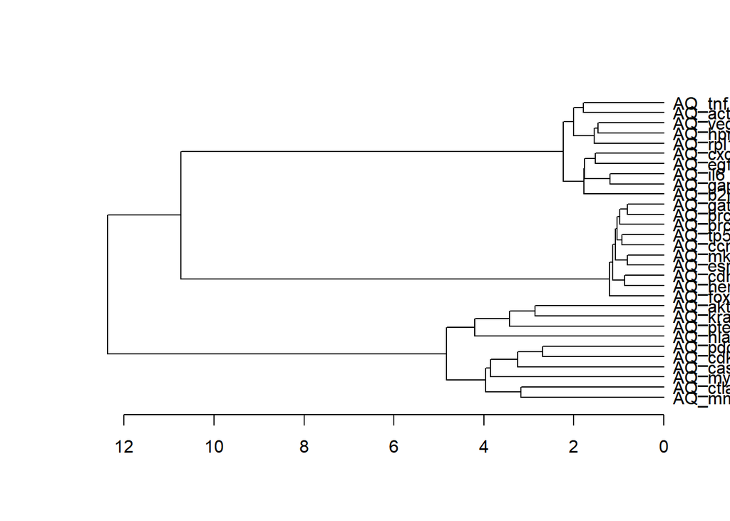

```r
set.seed(1995)

df2_scaled <- scale(df2[sapply(df2, is.numeric)])

aq_df <- df2_scaled[, grepl("^AQ", colnames(df2_scaled))]
aq_mat <- t(aq_df)

# Clustering y dendrograma
hclust_gen <- hclust(dist(aq_mat), method = "complete")

plot(as.dendrogram(hclust_gen),
     horiz = TRUE)
```

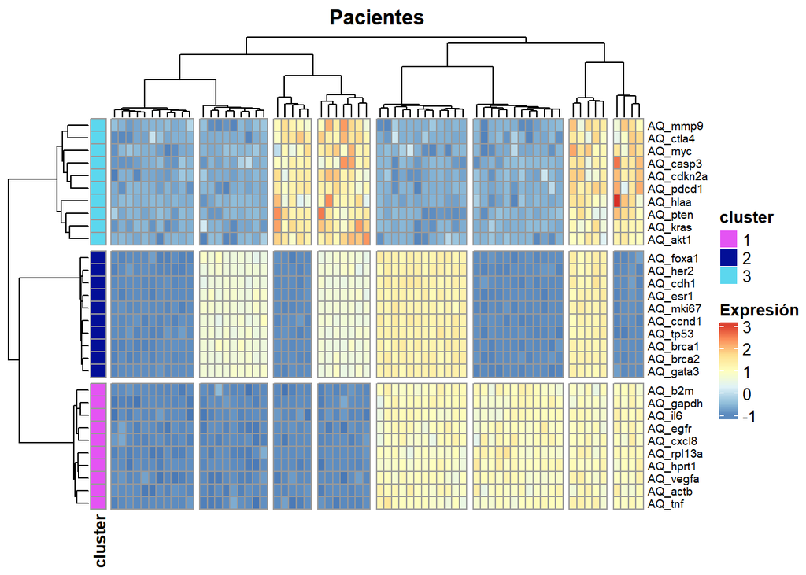

```r
# Anotación por clúster
my_gene_col <- cutree(as.dendrogram(hclust_gen), k = 3)
my_gene_col <- data.frame(cluster = factor(my_gene_col))

# Creo el heatmap con pheatmap
pheatmap(aq_mat,
         cutree_rows = 3,
         cutree_cols = 8,
         name = "Expresión",
         annotation_row = my_gene_col,
         main = "Pacientes",
         fontsize_row = 7)
```

Como se puede observar tanto en el heatmap como en su dendrograma en la parte superior, hay una clara división de los pacientes basándose en la similitud de sus perfiles de expresión de genes. Se aprecia una división en ocho bloques con patrones de expresión distinta. Dentro de estos ocho bloques, se pueden distinguir tres patrones: patrón de infraexpresión (colores azules), en los que muestran una baja o nula expresión en todos los clústers de genes; patrones mixtos (colores blanquecinos, azules y naranjas), que dependiendo del clúster de genes muestran infraexpresión, sobreexpresión o expresión normal; y patrones de sobreexpresión (colores naranjas y rojos), que tienen una expresión alta en los clústers de genes. Según esta clasificación, hay 1 clúster que muestra un patrón de infraexpresión, 1 clúster que muestra un patrón de sobreexpresión y 6 clústers que muestran patrones mixtos.

En cuanto a los grupos de genes, se pueden apreciar tres clústers diferenciados: El primer clúster está formado por los genes B2M, GAPDH, IL6, EGFR, CXCL8, RPL13A, HPRT1, VEGFA, ACTB, TNF. El segundo clúster está formado por los genes FOXA1, HER2, CDH1, ESR1, MKI67, CCND1, TP53, BRCA1, BRCA2, GATA3. El tercer clúster está formado por los genes MMP9, CTLA4, MYC, CASP3, CDKN2A, PDCD1, HLA-A, PTEN, KRAS, AKT1.